# Honduras1 Summary Report

27/05/2026

## Survey Summary

**Data Collection Dates:** : 2026-01-08 - 2026-01-19

| Form | N |
| --- | --- |
| Indicators Form | 40 |
| Womens Form | 40 |
| Completed both forms | 40 |
| Completed only indicator form | 0 |
| Completed only womens form | 0 |

## Sample Demographics

| **Characteristic** | **N = 40**<sup>1</sup> |
| --- | --- |
| loc1_name |  |
| Langue | 40 (100%) |
| Respondent Sex |  |
| F | 34 (85%) |
| M | 6 (15%) |
| Respondent Age | 49 (33, 56) |
| Women's Form Respondent Age | 50 (32, 57) |
| Education (Household Head) |  |
| No school | 1 (2.5%) |
| Primary | 30 (75%) |
| Secondary | 8 (20%) |
| Post-Secondary | 0 (0%) |
| Adult education, literacy school or parish school | 0 (0%) |
| No answer | 1 (2.5%) |

<sup>1</sup> n (%); Median (Q1, Q3)

## Indicator Summary

| Indicator | Estimate |
| --- | --- |
| PO.1 |  |
| Total Number of Crops (Median) | 3 |
| Total Number of Important Crops (Median) | 2 |
| Gini-Simpson Diversity Index (Median) | 0.07 |
| Median % of farm area used for staple crop production (Millet, Maize, Sorghum & Wheat) | 77.0% |
| PO.2 |  |
| Women's Decision Making - Crops grown for food | 76.9% |
| Women's Decision Making - Crops grown for the market | 83.8% |
| Women's Decision Making - Expenditure of household savings | 77.5% |
| Women's Decision Making - Choose how to spend their own income | 82.5% |
| Women's Decision Making - Choose what to sell in the market | 68.4% |
| Women's Decision Making - Participate in community committees – specifically can they choose how they allocate time to community groups, farm work, etc. | 85.0% |
| % of women having sole/joint ownership of at least one major or two minor assets: | 100.0% |
| Median % of household assets owned solely/jointly by women | 100.0% |
| PO.3 |  |
| % of households with at least 2 different sources of income | 40.0% |
| Financial situation - “We can buy everything we want and there is still money for potential savings” | 67.5% |
| Does your household have any credit, debts or loans, or did you have any in the last 12 months?: | 30.0% |
| Did you ever find it difficult to pay the debts in the last 12 months | 20.0% |
| PO.4 |  |
| Minimum Dietary Diversity (5 food groups) | 100.0% |
| Estimated % of households with moderate or severe food insecurity: | 54.1% |
| Estimated % of households with severe food insecurity: | 2.9% |

## PO.1 Productivity

**Objective Definition** : Smallholder farm households have improved their capacity to increase productivity and food security by transitioning their farming systems through agroecological methods.

### Crop Production

| Crop | N (%) | Mean Area (Ha) | Mean Yield (Kg) | Mean Productivity (Kg/Ha) |
| --- | --- | --- | --- | --- |
| Maize | 36 (90.0%) | 1.01 | 5,808 | 8,650 |
| Red Beans | 10 (25.0%) | 0.88 | 1,049 | 1,699 |
| Cassava | 8 (20.0%) | 0.18 | 537 | 3,856 |
| Beans | 8 (20.0%) | 0.47 | 2,993 | 4,625 |
| Sorghum | 6 (15.0%) | 2.10 | 484 | 1,630 |
| Squash | 4 (10.0%) | 0.04 | 60 | 1,371 |
| Bananas | 3 (7.5%) | 0.22 |  |  |
| Sweet Potato | 2 (5.0%) | 0.02 | 7 | 13,605 |
| Kidney Beans | 2 (5.0%) | 0.71 | 499 | 708 |
| Nance Fruit | 2 (5.0%) | 0.04 | 27 | 622 |
| Chilli Peppers | 1 (2.5%) |  |  |  |
| Orange Trees | 1 (2.5%) | 0.04 | 91 | 2,075 |
| Pineapple | 1 (2.5%) | 0.17 | 4,000 | 22,857 |
| Mango | 1 (2.5%) | 0.09 | 908 | 10,377 |
| Coconut | 1 (2.5%) | 0.04 | 40 | 914 |
| Sweet Chili | 1 (2.5%) |  |  |  |
| Chipilín | 1 (2.5%) | 0.09 |  |  |

Missing entries result of using measurment units wihtout confrimed coversions to KG and/or HA

**Number of crops grown in a farm**

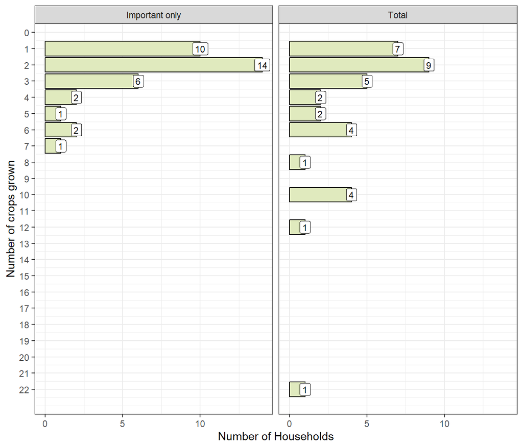

**Area of main crops (Ha)**

The following box plot shows the distribution of crop production areas (in hectares) for all crops grown by at least 5 respondents. The box represents the interquartile range (IQR) of the data, with the line inside the box indicating the median. The whiskers extend to 1.5 times the IQR, and any points beyond this range are considered outliers and are not shown in this plot.

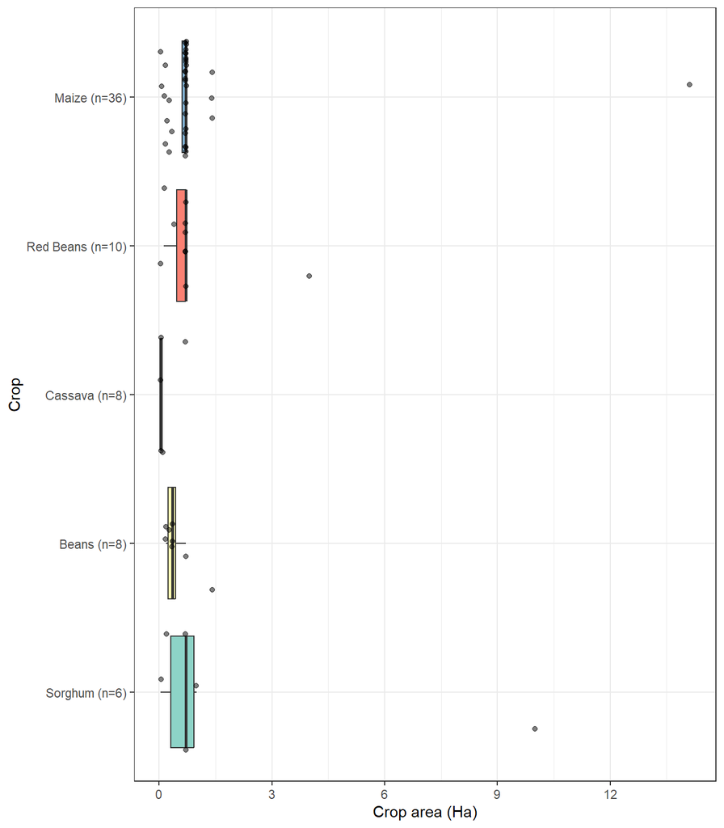

**Crop Yields (Kg/Ha)**

The following box plot shows the distribution of crop yields (in Kg/Ha) for all crops grown by at least 5 respondents. The box represents the interquartile range (IQR) of the data, with the line inside the box indicating the median. The whiskers extend to 1.5 times the IQR, and any points beyond this range are considered outliers and are not shown in this plot.

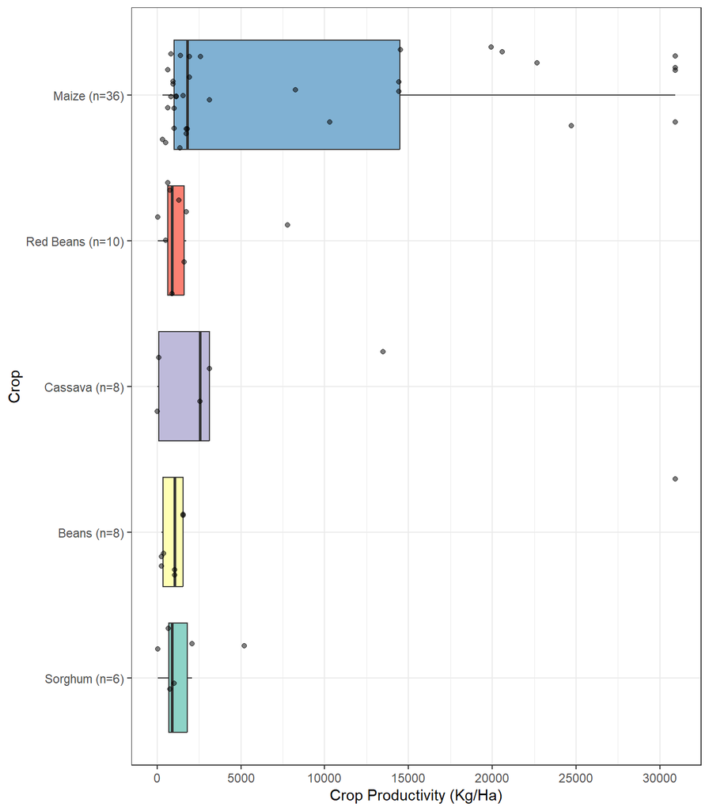

**Crop Diversity**

The Gini-Simpson Diversity Index measures the probability that two randomly selected individuals from a population belong to different groups or categories. For the purposes of this implementation, this index is instead calculated using the yields of each crop listed as important (as we do not have detailed production information on the other harvested crops). Therefore scores may be considered an underestimate of the total farming system.

A higher score indicators a higher level of diversity in a farm’s crop production, while a score of 0 indicates a monoculture farming operation.

| **Characteristic** | **N = 40** |
| --- | --- |
| Gini-Simpson Diversity Index |  |
| Mean (SD) | 0.19 (0.23) |
| Median (Q1, Q3) | 0.07 (0.00, 0.34) |
| Min, Max | 0.00, 0.66 |
| Unknown | 5 |

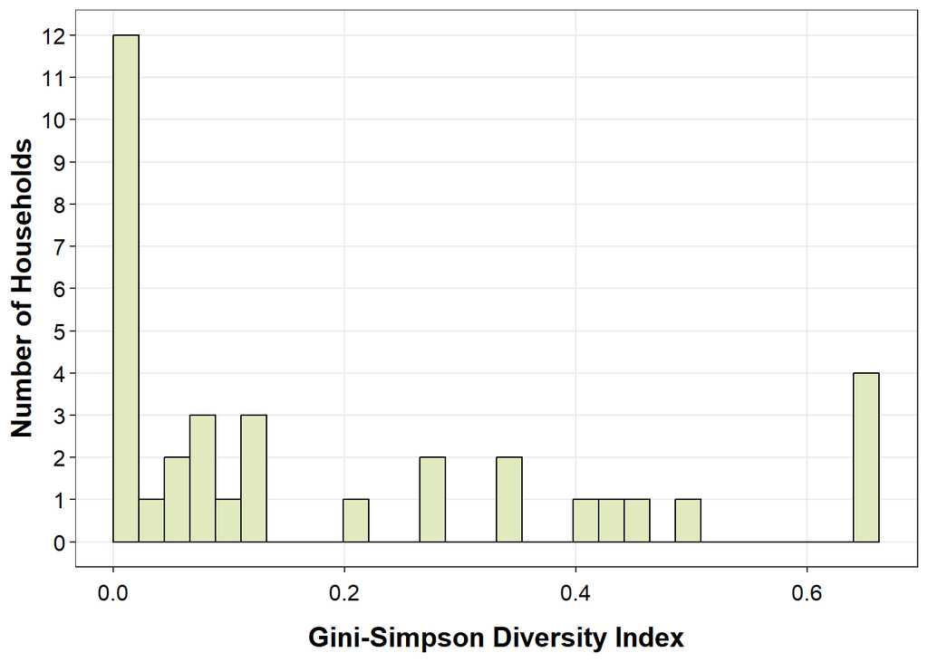

## PO.2 Womens Empowerment

**Objective Definition** : Women farmers have gained greater control over productive resources and decision making in their households and communities.

**Proportion of households where women have equal/more influence or voice about…**

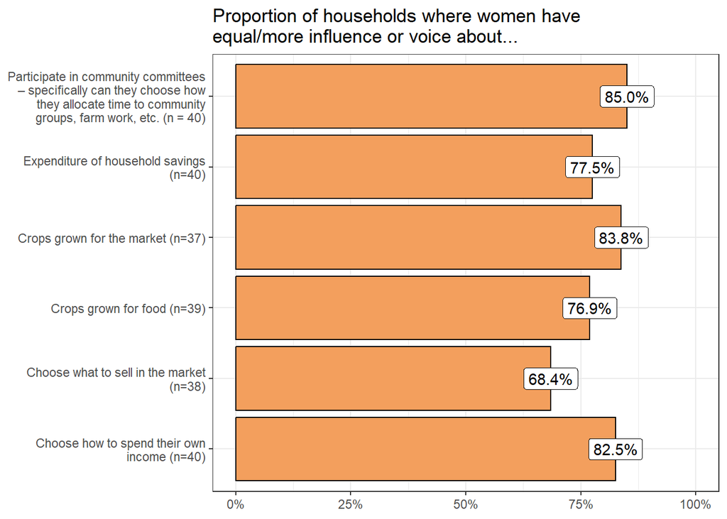

**A-WEAI - Access to productive capital**

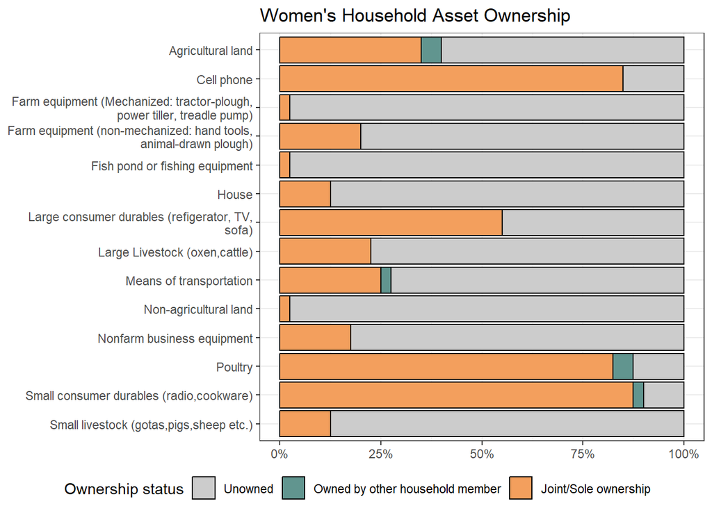

| Asset | Joint/Sole ownership | Unowned | Owned by other household member |
| --- | --- | --- | --- |
| Agricultural land | 35.0% | 60.0% | 5.0% |
| Large Livestock (oxen,cattle) | 22.5% | 77.5% | 0.0% |
| Small livestock (gotas,pigs,sheep etc.) | 12.5% | 87.5% | 0.0% |
| Poultry | 82.5% | 12.5% | 5.0% |
| Fish pond or fishing equipment | 2.5% | 97.5% | 0.0% |
| Farm equipment (non-mechanized: hand tools, animal-drawn plough) | 20.0% | 80.0% | 0.0% |
| Farm equipment (Mechanized: tractor-plough, power tiller, treadle pump) | 2.5% | 97.5% | 0.0% |
| Nonfarm business equipment | 17.5% | 82.5% | 0.0% |
| House | 12.5% | 87.5% | 0.0% |
| Large consumer durables (refigerator, TV, sofa) | 55.0% | 45.0% | 0.0% |
| Small consumer durables (radio,cookware) | 87.5% | 10.0% | 2.5% |
| Cell phone | 85.0% | 15.0% | 0.0% |
| Non-agricultural land | 2.5% | 97.5% | 0.0% |
| Means of transportation | 25.0% | 72.5% | 2.5% |

## PO.3 Household Income

**Objective Definition** : Smallholder farm households have sustainably increased their incomes and diversified their livelihoods with an emphasis on local markets.

### Markets

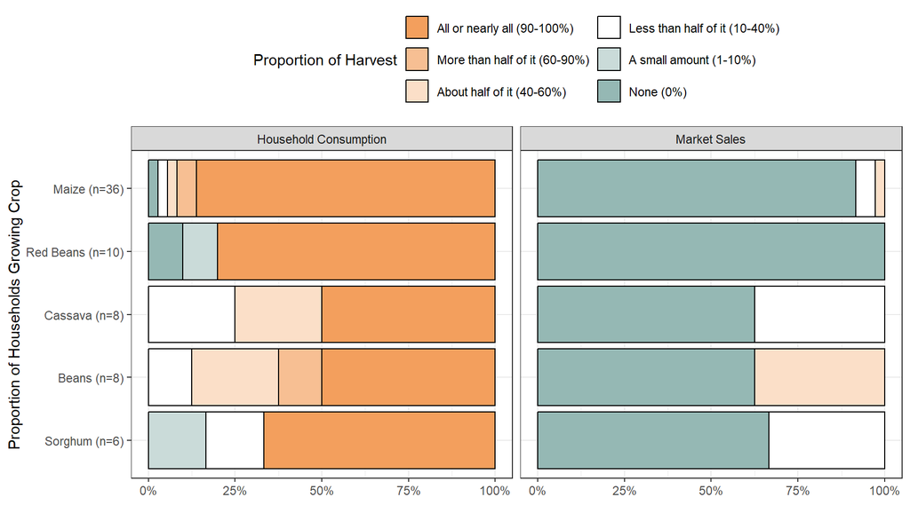

|  | **Beans** N = 8<sup>1</sup> | **Cassava** N = 8<sup>1</sup> | **Maize** N = 36<sup>1</sup> | **Red Beans** N = 10<sup>1</sup> | **Sorghum** N = 6<sup>1</sup> |
| --- | --- | --- | --- | --- | --- |
| Household Consumption |  |  |  |  |  |
| All or nearly all (90-100%) | 4 (50%) | 4 (50%) | 31 (86%) | 8 (80%) | 4 (67%) |
| More than half of it (60-90%) | 1 (13%) | 0 (0%) | 2 (5.6%) | 0 (0%) | 0 (0%) |
| About half of it (40-60%) | 2 (25%) | 2 (25%) | 1 (2.8%) | 0 (0%) | 0 (0%) |
| Less than half of it (10-40%) | 1 (13%) | 2 (25%) | 1 (2.8%) | 0 (0%) | 1 (17%) |
| A small amount (1-10%) | 0 (0%) | 0 (0%) | 0 (0%) | 1 (10%) | 1 (17%) |
| None (0%) | 0 (0%) | 0 (0%) | 1 (2.8%) | 1 (10%) | 0 (0%) |
| No answer | 0 (0%) | 0 (0%) | 0 (0%) | 0 (0%) | 0 (0%) |
| Market Sales |  |  |  |  |  |
| All or nearly all (90-100%) | 0 (0%) | 0 (0%) | 0 (0%) | 0 (0%) | 0 (0%) |
| More than half of it (60-90%) | 0 (0%) | 0 (0%) | 0 (0%) | 0 (0%) | 0 (0%) |
| About half of it (40-60%) | 3 (38%) | 0 (0%) | 1 (2.8%) | 0 (0%) | 0 (0%) |
| Less than half of it (10-40%) | 0 (0%) | 3 (38%) | 2 (5.6%) | 0 (0%) | 2 (33%) |
| A small amount (1-10%) | 0 (0%) | 0 (0%) | 0 (0%) | 0 (0%) | 0 (0%) |
| None (0%) | 5 (63%) | 5 (63%) | 33 (92%) | 10 (100%) | 4 (67%) |
| No answer | 0 (0%) | 0 (0%) | 0 (0%) | 0 (0%) | 0 (0%) |

<sup>1</sup> n (%)

### Income Diversification

**Diversity & Importance of Income Sources**

| **Characteristic** | **N = 40**<sup>1</sup> |
| --- | --- |
| Income Source |  |
| Crop farming + Off-farm sources | 16 (40%) |
| Crop farming only | 20 (50%) |
| Income sources unreported | 2 (5.0%) |
| Off-farm sources only | 2 (5.0%) |

<sup>1</sup> n (%)

| Income Source | Households (n) | % |
| --- | --- | --- |
| Labour on other farms | 2 | 5.0% |
| Labour, not on a farm | 2 | 5.0% |
| Have own business | 4 | 10.0% |
| Remittances (send money) | 10 | 25.0% |
| Other | 1 | 2.5% |

### Ability to Save & Pay Debts

Households reporting their financial situation as “We can buy everything we want and there is still money for potential savings”: 67.5%

Does your household have any credit, debts or loans, or did you have any in the last 12 months?: 30.0%

Did you ever find it difficult to pay the debts in the last 12 months: 20.0%

### Self-Perception of Financial Situation

|  | **N = 40**<sup>1</sup> |
| --- | --- |
| Self-Perception of financial situation |  |
| We can buy everything we want and there is still money for potential savings | 27 (68%) |
| We can buy everything we want without specific problems but we are not able to save | 0 (0%) |
| We live economically and so we can afford everything | 10 (25%) |
| We live very economically in order to save money for important purchases / events | 3 (7.5%) |
| We can buy only the cheapest food clothes and rent the cheapest apartment and (if the household is in debt) ‐ for loan repayment | 0 (0%) |
| We can only buy the cheapest food and we have no money to repay the loan or to pay for new clothes or rent | 0 (0%) |
| We can not afford even the cheapest food | 0 (0%) |

<sup>1</sup> n (%)

## PO.4 Food Security & Dietary Diversity

**Objective Definition** : Vulnerable households have improved dietary diversity and nutritional status.

### Household Dietary Diversity

Household dietary diversity is defined by asking the respondent which of the following 12 food groups did they consume within the last 24 hours including; grains, roots & tubers, pulses, vegetables, fruits, meat & poultry, eggs, fish & seafood, milk & dairy, oils & fats, packaged sweets or honey and miscellaneous others. Scores will range between 0 and 12. A score of 0 would reflect a household going a whole day without eating, a score of 12 suggests every listed food group was consumed within the household.

Note: During the pilot phase of groundswell, these questions only included the responding woman of the household in the wording. Future implementations will reflect the whole household.

% Households Reached minimum level of diversity (at least 5 food groups): 100.0%

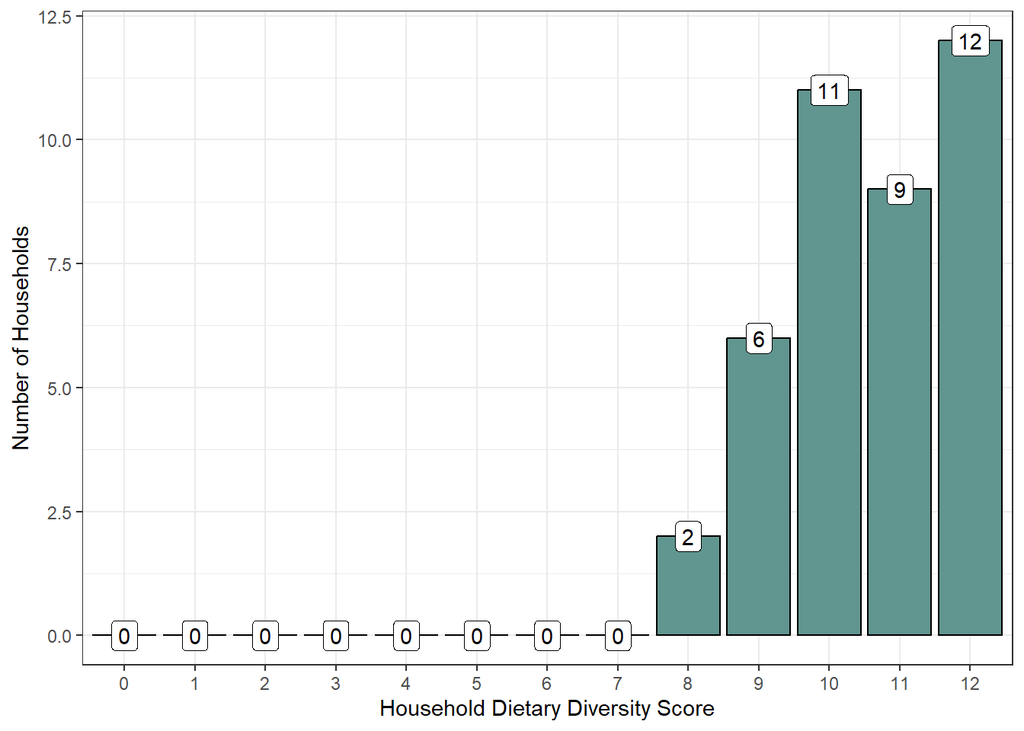

### FIES (Food Insecurity)

The Food Insecurity Experience Scale (FIES) assesses a households recent history of food security through 8 questions. For each question, the responding woman will answer whether or not the household exhibited certain events due to a lack of money or resources over the last 12 months. These include being unable to east healthy foods, skipping meals, and going a whole day without eating.

Each behaviour experienced increases the FIES score by 1, therefore lower scores represent greater food security while high scores reflect high insecurity. Households may additional be categorised based on which specific events they experienced.

- Food Secure = No food insecure events experienced
- Mildly Insecure = Experienced worrying about not having enough to eat, being unable to eat healthy food, eating only a few kinds of foods or skipping a meal
- Moderately Insecure = Experienced eating less than they thought they should, running out of food or were hungry but not eat.
- Severely Insecure = Experienced going a whole day without eating

Estimated % of households with moderate or severe food insecurity: 54.1%

Estimated % of households with severe food insecurity: 2.9%

[output not shown]

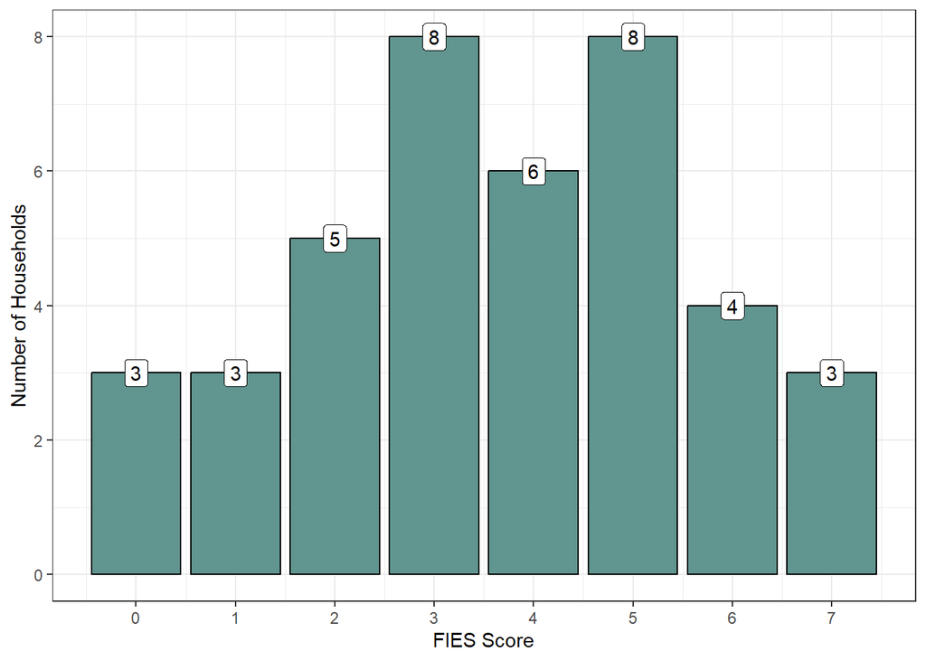

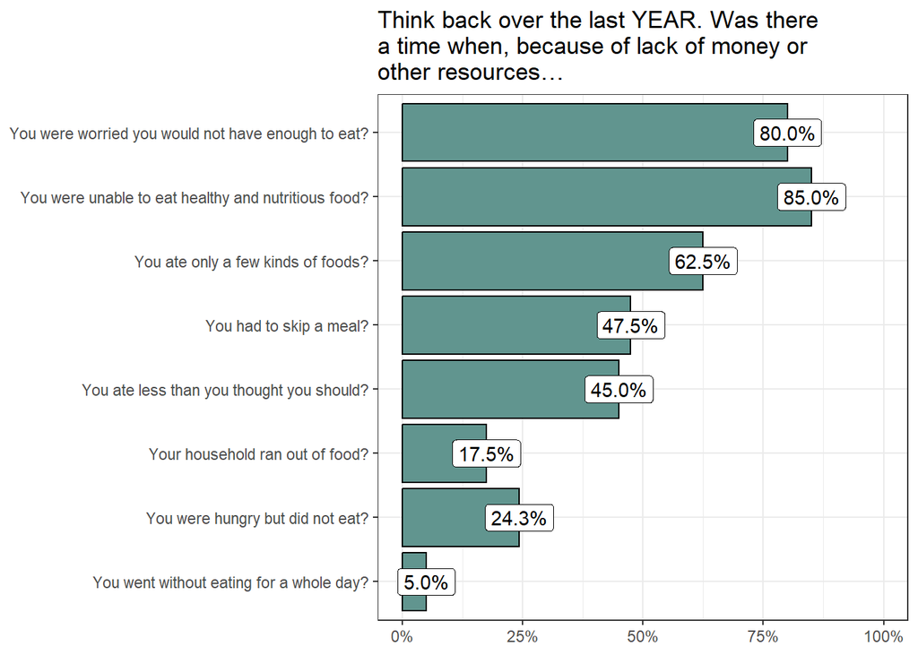